# Risk Factor Analysis

## Outcome Variable

**Outcome Variable:** y_rate_haz

## Predictor Variables

**Intervention Variable:** nchldlt5

**Adjustment Set:**

- arm
- W_mage
- meducyrs
- feducyrs
- hhwealth_quart
- hfoodsec
- W_mhtcm
- W_nrooms
- W_parity
- impfloor
- impsan
- safeh20
- delta_W_mage
- delta_meducyrs
- delta_feducyrs
- delta_hhwealth_quart
- delta_hfoodsec
- delta_W_mhtcm
- delta_W_nrooms
- delta_W_parity
- delta_impfloor
- delta_impsan
- delta_safeh20

## Stratifying Variables

The analysis was stratified on these variable(s):

- agecat
- studyid
- country

## Data Summary

| agecat | studyid | country | nchldlt5 | n_cell | n |
| --- | --- | --- | --- | --- | --- |
| 0-3 months | ki1000108-IRC | INDIA | 1 | 82 | 268 |
| 0-3 months | ki1000108-IRC | INDIA | 2+ | 186 | 268 |
| 0-3 months | ki1017093b-PROVIDE | BANGLADESH | 1 | 467 | 476 |
| 0-3 months | ki1017093b-PROVIDE | BANGLADESH | 2+ | 9 | 476 |
| 0-3 months | ki1017093c-NIH-Crypto | BANGLADESH | 1 | 511 | 517 |
| 0-3 months | ki1017093c-NIH-Crypto | BANGLADESH | 2+ | 6 | 517 |
| 0-3 months | kiGH5241-JiVitA-3 | BANGLADESH | 1 | 24944 | 25864 |
| 0-3 months | kiGH5241-JiVitA-3 | BANGLADESH | 2+ | 920 | 25864 |
| 3-6 months | ki1000108-IRC | INDIA | 1 | 87 | 283 |
| 3-6 months | ki1000108-IRC | INDIA | 2+ | 196 | 283 |
| 3-6 months | ki1017093b-PROVIDE | BANGLADESH | 1 | 421 | 429 |
| 3-6 months | ki1017093b-PROVIDE | BANGLADESH | 2+ | 8 | 429 |
| 3-6 months | ki1017093c-NIH-Crypto | BANGLADESH | 1 | 492 | 497 |
| 3-6 months | ki1017093c-NIH-Crypto | BANGLADESH | 2+ | 5 | 497 |
| 3-6 months | ki1066203-TanzaniaChild2 | TANZANIA, UNITED REPUBLIC OF | 1 | 1145 | 1194 |
| 3-6 months | ki1066203-TanzaniaChild2 | TANZANIA, UNITED REPUBLIC OF | 2+ | 49 | 1194 |
| 3-6 months | kiGH5241-JiVitA-3 | BANGLADESH | 1 | 16204 | 16720 |
| 3-6 months | kiGH5241-JiVitA-3 | BANGLADESH | 2+ | 516 | 16720 |
| 6-12 months | ki1000108-IRC | INDIA | 1 | 88 | 284 |
| 6-12 months | ki1000108-IRC | INDIA | 2+ | 196 | 284 |
| 6-12 months | ki1017093b-PROVIDE | BANGLADESH | 1 | 399 | 407 |
| 6-12 months | ki1017093b-PROVIDE | BANGLADESH | 2+ | 8 | 407 |
| 6-12 months | ki1017093c-NIH-Crypto | BANGLADESH | 1 | 474 | 478 |
| 6-12 months | ki1017093c-NIH-Crypto | BANGLADESH | 2+ | 4 | 478 |
| 6-12 months | ki1066203-TanzaniaChild2 | TANZANIA, UNITED REPUBLIC OF | 1 | 769 | 798 |
| 6-12 months | ki1066203-TanzaniaChild2 | TANZANIA, UNITED REPUBLIC OF | 2+ | 29 | 798 |
| 6-12 months | ki1148112-LCNI-5 | MALAWI | 1 | 205 | 233 |
| 6-12 months | ki1148112-LCNI-5 | MALAWI | 2+ | 28 | 233 |
| 6-12 months | kiGH5241-JiVitA-3 | BANGLADESH | 1 | 12583 | 12993 |
| 6-12 months | kiGH5241-JiVitA-3 | BANGLADESH | 2+ | 410 | 12993 |
| 12-24 months | ki1000108-IRC | INDIA | 1 | 86 | 280 |
| 12-24 months | ki1000108-IRC | INDIA | 2+ | 194 | 280 |
| 12-24 months | ki1017093b-PROVIDE | BANGLADESH | 1 | 331 | 337 |
| 12-24 months | ki1017093b-PROVIDE | BANGLADESH | 2+ | 6 | 337 |
| 12-24 months | ki1017093c-NIH-Crypto | BANGLADESH | 1 | 341 | 344 |
| 12-24 months | ki1017093c-NIH-Crypto | BANGLADESH | 2+ | 3 | 344 |
| 12-24 months | ki1066203-TanzaniaChild2 | TANZANIA, UNITED REPUBLIC OF | 1 | 1 | 1 |
| 12-24 months | ki1066203-TanzaniaChild2 | TANZANIA, UNITED REPUBLIC OF | 2+ | 0 | 1 |
| 12-24 months | ki1148112-LCNI-5 | MALAWI | 1 | 152 | 171 |
| 12-24 months | ki1148112-LCNI-5 | MALAWI | 2+ | 19 | 171 |
| 12-24 months | kiGH5241-JiVitA-3 | BANGLADESH | 1 | 5807 | 6033 |
| 12-24 months | kiGH5241-JiVitA-3 | BANGLADESH | 2+ | 226 | 6033 |

The following strata were considered:

- agecat: 0-3 months, studyid: ki1000108-IRC, country: INDIA
- agecat: 0-3 months, studyid: ki1017093b-PROVIDE, country: BANGLADESH
- agecat: 0-3 months, studyid: ki1017093c-NIH-Crypto, country: BANGLADESH
- agecat: 0-3 months, studyid: kiGH5241-JiVitA-3, country: BANGLADESH
- agecat: 12-24 months, studyid: ki1000108-IRC, country: INDIA
- agecat: 12-24 months, studyid: ki1017093b-PROVIDE, country: BANGLADESH
- agecat: 12-24 months, studyid: ki1017093c-NIH-Crypto, country: BANGLADESH
- agecat: 12-24 months, studyid: ki1066203-TanzaniaChild2, country: TANZANIA, UNITED REPUBLIC OF
- agecat: 12-24 months, studyid: ki1148112-LCNI-5, country: MALAWI
- agecat: 12-24 months, studyid: kiGH5241-JiVitA-3, country: BANGLADESH
- agecat: 3-6 months, studyid: ki1000108-IRC, country: INDIA
- agecat: 3-6 months, studyid: ki1017093b-PROVIDE, country: BANGLADESH
- agecat: 3-6 months, studyid: ki1017093c-NIH-Crypto, country: BANGLADESH
- agecat: 3-6 months, studyid: ki1066203-TanzaniaChild2, country: TANZANIA, UNITED REPUBLIC OF
- agecat: 3-6 months, studyid: kiGH5241-JiVitA-3, country: BANGLADESH
- agecat: 6-12 months, studyid: ki1000108-IRC, country: INDIA
- agecat: 6-12 months, studyid: ki1017093b-PROVIDE, country: BANGLADESH
- agecat: 6-12 months, studyid: ki1017093c-NIH-Crypto, country: BANGLADESH
- agecat: 6-12 months, studyid: ki1066203-TanzaniaChild2, country: TANZANIA, UNITED REPUBLIC OF
- agecat: 6-12 months, studyid: ki1148112-LCNI-5, country: MALAWI
- agecat: 6-12 months, studyid: kiGH5241-JiVitA-3, country: BANGLADESH

### Dropped Strata

Some strata were dropped due to rare outcomes:

- agecat: 6-12 months, studyid: ki1017093c-NIH-Crypto, country: BANGLADESH
- agecat: 12-24 months, studyid: ki1017093c-NIH-Crypto, country: BANGLADESH
- agecat: 12-24 months, studyid: ki1066203-TanzaniaChild2, country: TANZANIA, UNITED REPUBLIC OF

## Methods Detail

We’re interested in the causal parameters $E[Y_a]$ for all values of $a \in \mathcal{A}$. These parameters represent the mean outcome if, possibly contrary to fact, we intervened to set all units to have $A=a$. Under the randomization and positivity assumptions, these are identified by the statistical parameters $\psi_a=E_W[E_{Y|A,W}(Y|A=a,W)]$. In addition, we’re interested in the mean of $Y$, $E[Y]$ under no intervention (the observed mean). We will estimate these parameters by using SuperLearner to fit the relevant likelihood factors – $E_{Y|A,W}(Y|A=a,W)$ and $p(A=a|W)$, and then updating our likelihood fit using a joint TMLE.

For unadjusted analyses ($W=\{\}$), initial likelihoods were estimated using Lrnr_glm to estimate the simple $E(Y|A)$ and Lrnr_mean to estimate $p(A)$. For adjusted analyses, a small library containing Lrnr_glmnet, Lrnr_xgboost, and Lrnr_mean was used.

Having estimated these parameters, we will then use the delta method to estimate relative risks and attributable risks relative to a prespecified baseline level of $A$.

# Results Detail

## Results Plots

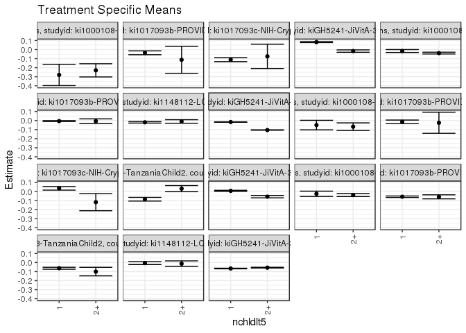

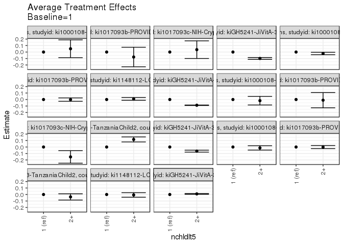

## Results Table

### Parameter: TSM

| agecat | studyid | country | intervention_level | baseline_level | estimate | ci_lower | ci_upper |
| --- | --- | --- | --- | --- | --- | --- | --- |
| 0-3 months | ki1000108-IRC | INDIA | 1 | NA | -0.2797297 | -0.3976036 | -0.1618557 |
| 0-3 months | ki1000108-IRC | INDIA | 2+ | NA | -0.2291567 | -0.3019849 | -0.1563285 |
| 0-3 months | ki1017093b-PROVIDE | BANGLADESH | 1 | NA | -0.0354425 | -0.0565912 | -0.0142939 |
| 0-3 months | ki1017093b-PROVIDE | BANGLADESH | 2+ | NA | -0.1123006 | -0.2613938 | 0.0367927 |
| 0-3 months | ki1017093c-NIH-Crypto | BANGLADESH | 1 | NA | -0.1111297 | -0.1331115 | -0.0891480 |
| 0-3 months | ki1017093c-NIH-Crypto | BANGLADESH | 2+ | NA | -0.0744920 | -0.2086755 | 0.0596915 |
| 0-3 months | kiGH5241-JiVitA-3 | BANGLADESH | 1 | NA | 0.0826111 | 0.0769935 | 0.0882287 |
| 0-3 months | kiGH5241-JiVitA-3 | BANGLADESH | 2+ | NA | -0.0163277 | -0.0295451 | -0.0031103 |
| 3-6 months | ki1000108-IRC | INDIA | 1 | NA | -0.0500169 | -0.1024750 | 0.0024412 |
| 3-6 months | ki1000108-IRC | INDIA | 2+ | NA | -0.0676003 | -0.1094426 | -0.0257579 |
| 3-6 months | ki1017093b-PROVIDE | BANGLADESH | 1 | NA | -0.0141139 | -0.0336071 | 0.0053792 |
| 3-6 months | ki1017093b-PROVIDE | BANGLADESH | 2+ | NA | -0.0245420 | -0.1407904 | 0.0917063 |
| 3-6 months | ki1017093c-NIH-Crypto | BANGLADESH | 1 | NA | 0.0351356 | 0.0155165 | 0.0547548 |
| 3-6 months | ki1017093c-NIH-Crypto | BANGLADESH | 2+ | NA | -0.1176585 | -0.2120708 | -0.0232463 |
| 3-6 months | ki1066203-TanzaniaChild2 | TANZANIA, UNITED REPUBLIC OF | 1 | NA | -0.0851252 | -0.1054563 | -0.0647941 |
| 3-6 months | ki1066203-TanzaniaChild2 | TANZANIA, UNITED REPUBLIC OF | 2+ | NA | 0.0316436 | -0.0021121 | 0.0653993 |
| 3-6 months | kiGH5241-JiVitA-3 | BANGLADESH | 1 | NA | 0.0071414 | 0.0012029 | 0.0130799 |
| 3-6 months | kiGH5241-JiVitA-3 | BANGLADESH | 2+ | NA | -0.0566370 | -0.0698877 | -0.0433864 |
| 6-12 months | ki1000108-IRC | INDIA | 1 | NA | -0.0252479 | -0.0544549 | 0.0039591 |
| 6-12 months | ki1000108-IRC | INDIA | 2+ | NA | -0.0390297 | -0.0555260 | -0.0225335 |
| 6-12 months | ki1017093b-PROVIDE | BANGLADESH | 1 | NA | -0.0575360 | -0.0657072 | -0.0493648 |
| 6-12 months | ki1017093b-PROVIDE | BANGLADESH | 2+ | NA | -0.0587582 | -0.0810227 | -0.0364937 |
| 6-12 months | ki1066203-TanzaniaChild2 | TANZANIA, UNITED REPUBLIC OF | 1 | NA | -0.0633691 | -0.0740703 | -0.0526678 |
| 6-12 months | ki1066203-TanzaniaChild2 | TANZANIA, UNITED REPUBLIC OF | 2+ | NA | -0.1006254 | -0.1478495 | -0.0534013 |
| 6-12 months | ki1148112-LCNI-5 | MALAWI | 1 | NA | -0.0062296 | -0.0225341 | 0.0100749 |
| 6-12 months | ki1148112-LCNI-5 | MALAWI | 2+ | NA | -0.0130468 | -0.0437349 | 0.0176413 |
| 6-12 months | kiGH5241-JiVitA-3 | BANGLADESH | 1 | NA | -0.0665991 | -0.0700173 | -0.0631810 |
| 6-12 months | kiGH5241-JiVitA-3 | BANGLADESH | 2+ | NA | -0.0573134 | -0.0617343 | -0.0528925 |
| 12-24 months | ki1000108-IRC | INDIA | 1 | NA | -0.0159737 | -0.0319643 | 0.0000169 |
| 12-24 months | ki1000108-IRC | INDIA | 2+ | NA | -0.0387693 | -0.0488054 | -0.0287332 |
| 12-24 months | ki1017093b-PROVIDE | BANGLADESH | 1 | NA | -0.0059797 | -0.0106109 | -0.0013484 |
| 12-24 months | ki1017093b-PROVIDE | BANGLADESH | 2+ | NA | -0.0071792 | -0.0329161 | 0.0185578 |
| 12-24 months | ki1148112-LCNI-5 | MALAWI | 1 | NA | -0.0194209 | -0.0277618 | -0.0110800 |
| 12-24 months | ki1148112-LCNI-5 | MALAWI | 2+ | NA | -0.0100139 | -0.0295286 | 0.0095008 |
| 12-24 months | kiGH5241-JiVitA-3 | BANGLADESH | 1 | NA | -0.0166332 | -0.0189083 | -0.0143582 |
| 12-24 months | kiGH5241-JiVitA-3 | BANGLADESH | 2+ | NA | -0.1047939 | -0.1067868 | -0.1028011 |

### Parameter: E(Y)

| agecat | studyid | country | intervention_level | baseline_level | estimate | ci_lower | ci_upper |
| --- | --- | --- | --- | --- | --- | --- | --- |
| 0-3 months | ki1000108-IRC | INDIA | NA | NA | -0.2441698 | -0.3119044 | -0.1764352 |
| 0-3 months | ki1017093b-PROVIDE | BANGLADESH | NA | NA | -0.0368957 | -0.0578563 | -0.0159352 |
| 0-3 months | ki1017093c-NIH-Crypto | BANGLADESH | NA | NA | -0.1107045 | -0.1324895 | -0.0889195 |
| 0-3 months | kiGH5241-JiVitA-3 | BANGLADESH | NA | NA | 0.0813511 | 0.0757338 | 0.0869684 |
| 3-6 months | ki1000108-IRC | INDIA | NA | NA | -0.0586315 | -0.0951914 | -0.0220716 |
| 3-6 months | ki1017093b-PROVIDE | BANGLADESH | NA | NA | -0.0143084 | -0.0335609 | 0.0049441 |
| 3-6 months | ki1017093c-NIH-Crypto | BANGLADESH | NA | NA | 0.0335984 | 0.0141072 | 0.0530897 |
| 3-6 months | ki1066203-TanzaniaChild2 | TANZANIA, UNITED REPUBLIC OF | NA | NA | -0.0809860 | -0.1009833 | -0.0609888 |
| 3-6 months | kiGH5241-JiVitA-3 | BANGLADESH | NA | NA | 0.0052401 | -0.0005781 | 0.0110582 |
| 6-12 months | ki1000108-IRC | INDIA | NA | NA | -0.0337655 | -0.0491393 | -0.0183916 |
| 6-12 months | ki1017093b-PROVIDE | BANGLADESH | NA | NA | -0.0575601 | -0.0655826 | -0.0495375 |
| 6-12 months | ki1066203-TanzaniaChild2 | TANZANIA, UNITED REPUBLIC OF | NA | NA | -0.0648261 | -0.0753758 | -0.0542765 |
| 6-12 months | ki1148112-LCNI-5 | MALAWI | NA | NA | -0.0072589 | -0.0221468 | 0.0076290 |
| 6-12 months | kiGH5241-JiVitA-3 | BANGLADESH | NA | NA | -0.0678995 | -0.0712994 | -0.0644997 |
| 12-24 months | ki1000108-IRC | INDIA | NA | NA | -0.0327117 | -0.0417340 | -0.0236893 |
| 12-24 months | ki1017093b-PROVIDE | BANGLADESH | NA | NA | -0.0060010 | -0.0105729 | -0.0014292 |
| 12-24 months | ki1148112-LCNI-5 | MALAWI | NA | NA | -0.0183795 | -0.0261359 | -0.0106231 |
| 12-24 months | kiGH5241-JiVitA-3 | BANGLADESH | NA | NA | -0.0168950 | -0.0191616 | -0.0146285 |

### Parameter: ATE

| agecat | studyid | country | intervention_level | baseline_level | estimate | ci_lower | ci_upper |
| --- | --- | --- | --- | --- | --- | --- | --- |
| 0-3 months | ki1000108-IRC | INDIA | 1 | 1 | 0.0000000 | 0.0000000 | 0.0000000 |
| 0-3 months | ki1000108-IRC | INDIA | 2+ | 1 | 0.0505729 | -0.0868560 | 0.1880018 |
| 0-3 months | ki1017093b-PROVIDE | BANGLADESH | 1 | 1 | 0.0000000 | 0.0000000 | 0.0000000 |
| 0-3 months | ki1017093b-PROVIDE | BANGLADESH | 2+ | 1 | -0.0768580 | -0.2274438 | 0.0737277 |
| 0-3 months | ki1017093c-NIH-Crypto | BANGLADESH | 1 | 1 | 0.0000000 | 0.0000000 | 0.0000000 |
| 0-3 months | ki1017093c-NIH-Crypto | BANGLADESH | 2+ | 1 | 0.0366377 | -0.0993344 | 0.1726098 |
| 0-3 months | kiGH5241-JiVitA-3 | BANGLADESH | 1 | 1 | 0.0000000 | 0.0000000 | 0.0000000 |
| 0-3 months | kiGH5241-JiVitA-3 | BANGLADESH | 2+ | 1 | -0.0989388 | -0.1133333 | -0.0845443 |
| 3-6 months | ki1000108-IRC | INDIA | 1 | 1 | 0.0000000 | 0.0000000 | 0.0000000 |
| 3-6 months | ki1000108-IRC | INDIA | 2+ | 1 | -0.0175834 | -0.0837871 | 0.0486203 |
| 3-6 months | ki1017093b-PROVIDE | BANGLADESH | 1 | 1 | 0.0000000 | 0.0000000 | 0.0000000 |
| 3-6 months | ki1017093b-PROVIDE | BANGLADESH | 2+ | 1 | -0.0104281 | -0.1282995 | 0.1074433 |
| 3-6 months | ki1017093c-NIH-Crypto | BANGLADESH | 1 | 1 | 0.0000000 | 0.0000000 | 0.0000000 |
| 3-6 months | ki1017093c-NIH-Crypto | BANGLADESH | 2+ | 1 | -0.1527941 | -0.2492233 | -0.0563650 |
| 3-6 months | ki1066203-TanzaniaChild2 | TANZANIA, UNITED REPUBLIC OF | 1 | 1 | 0.0000000 | 0.0000000 | 0.0000000 |
| 3-6 months | ki1066203-TanzaniaChild2 | TANZANIA, UNITED REPUBLIC OF | 2+ | 1 | 0.1167688 | 0.0780125 | 0.1555251 |
| 3-6 months | kiGH5241-JiVitA-3 | BANGLADESH | 1 | 1 | 0.0000000 | 0.0000000 | 0.0000000 |
| 3-6 months | kiGH5241-JiVitA-3 | BANGLADESH | 2+ | 1 | -0.0637785 | -0.0788043 | -0.0487526 |
| 6-12 months | ki1000108-IRC | INDIA | 1 | 1 | 0.0000000 | 0.0000000 | 0.0000000 |
| 6-12 months | ki1000108-IRC | INDIA | 2+ | 1 | -0.0137819 | -0.0472796 | 0.0197159 |
| 6-12 months | ki1017093b-PROVIDE | BANGLADESH | 1 | 1 | 0.0000000 | 0.0000000 | 0.0000000 |
| 6-12 months | ki1017093b-PROVIDE | BANGLADESH | 2+ | 1 | -0.0012222 | -0.0249387 | 0.0224944 |
| 6-12 months | ki1066203-TanzaniaChild2 | TANZANIA, UNITED REPUBLIC OF | 1 | 1 | 0.0000000 | 0.0000000 | 0.0000000 |
| 6-12 months | ki1066203-TanzaniaChild2 | TANZANIA, UNITED REPUBLIC OF | 2+ | 1 | -0.0372564 | -0.0854546 | 0.0109418 |
| 6-12 months | ki1148112-LCNI-5 | MALAWI | 1 | 1 | 0.0000000 | 0.0000000 | 0.0000000 |
| 6-12 months | ki1148112-LCNI-5 | MALAWI | 2+ | 1 | -0.0068172 | -0.0417596 | 0.0281252 |
| 6-12 months | kiGH5241-JiVitA-3 | BANGLADESH | 1 | 1 | 0.0000000 | 0.0000000 | 0.0000000 |
| 6-12 months | kiGH5241-JiVitA-3 | BANGLADESH | 2+ | 1 | 0.0092858 | 0.0036912 | 0.0148803 |
| 12-24 months | ki1000108-IRC | INDIA | 1 | 1 | 0.0000000 | 0.0000000 | 0.0000000 |
| 12-24 months | ki1000108-IRC | INDIA | 2+ | 1 | -0.0227957 | -0.0416582 | -0.0039331 |
| 12-24 months | ki1017093b-PROVIDE | BANGLADESH | 1 | 1 | 0.0000000 | 0.0000000 | 0.0000000 |
| 12-24 months | ki1017093b-PROVIDE | BANGLADESH | 2+ | 1 | -0.0011995 | -0.0273498 | 0.0249508 |
| 12-24 months | ki1148112-LCNI-5 | MALAWI | 1 | 1 | 0.0000000 | 0.0000000 | 0.0000000 |
| 12-24 months | ki1148112-LCNI-5 | MALAWI | 2+ | 1 | 0.0094070 | -0.0117718 | 0.0305858 |
| 12-24 months | kiGH5241-JiVitA-3 | BANGLADESH | 1 | 1 | 0.0000000 | 0.0000000 | 0.0000000 |
| 12-24 months | kiGH5241-JiVitA-3 | BANGLADESH | 2+ | 1 | -0.0881607 | -0.0912523 | -0.0850690 |